# Introduction

- Smoking by pregnant women may result in fetal injury, premature birth, and low birth weight.
- Compare the birth weights of babies born to smokers and nonsmokers.
- Child Health and Development Studies (CHDS)—a comprehensive investigation of all pregnancies that occurred between 1960 and 1967 among women in the Kaiser Foundation Health Plan in the San Francisco–East Bay area (Yerushalmy [Yer71]).
- Birth weight is a measure of the baby’s maturity.
- Another measure of maturity is the baby’s gestational age, or the time spent in the womb.

# The Data

- The database includes all pregnancies that occurred between 1960 and 1967 among women in the Kaiser Foundation Health Plan in Oakland, California.
- A subset of this informa-tion collected for 1236 babies — those baby boys born during one year of the study who lived at least 28 days and who were single births.
- The information available for each baby is birth weight and whether or not the mother smoked during her pregnancy.

```r
babies<-read.table("babies.data", header=T)
head(babies)
```

| bwt | gestation | parity | age | height | weight | smoke |
| --- | --- | --- | --- | --- | --- | --- |
| 120 | 284 | 0 | 27 | 62 | 100 | 0 |
| 113 | 282 | 0 | 33 | 64 | 135 | 0 |
| 128 | 279 | 0 | 28 | 64 | 115 | 1 |
| 123 | 999 | 0 | 36 | 69 | 190 | 0 |
| 108 | 282 | 0 | 23 | 67 | 125 | 1 |
| 136 | 286 | 0 | 25 | 62 | 93 | 0 |

# Background

- Fetal Development
- Rubella
- A Physical Model

```r
#data來源https://www.stat.berkeley.edu/users/statlabs/labs.html
babies<-read.table("babies.data", header=T)
babiesI<-cbind(babies[1],babies[7])
colnames(babiesI) = c("Birth weight","Smoking status")
babiesI_tra<-t(head(babiesI))#轉置
colnames(babiesI_tra)<-NULL
babiesI_tra
#nrow(babies)
```

| Birth weight | 120 | 113 | 128 | 123 | 108 | 136 |
| --- | --- | --- | --- | --- | --- | --- |
| Smoking status | 0 | 0 | 1 | 0 | 1 | 0 |

#### TABLE 1.1. Sample observations and data description for the 1236 babies in the Child Health and Development Studies subset.

```r
Weight_category<-c("<=1500", "1500–2000","2000–2500","2500–3000","3000-3500","3500+")
Nonsmoker<-c(792,406,78,11.6,2.2,3.8)
Smoker<-c(565,346,27,6.1,4.5,2.6)
z<- rbind(Weight_category,Nonsmoker,Smoker)
t(z)
```

| Weight_category | Nonsmoker | Smoker |
| --- | --- | --- |
| <=1500 | 792 | 565 |
| 1500–2000 | 406 | 346 |
| 2000–2500 | 78 | 27 |
| 2500–3000 | 11.6 | 6.1 |
| 3000-3500 | 2.2 | 4.5 |
| 3500+ | 3.8 | 2.6 |

#### TABLE 1.2. Neonatal mortality rates per 1000 births by birth weight (grams) for live-born infants of white mothers, according to smoking status (Yerushalmy [Yer71]).

[figure not shown]

#### FIGURE 1.2. Mortality curves for smokers and nonsmokers by kilograms (left plot) and by standard units (right plot) of birth weight for the Missouri study (Wilcox [Wil93]).

# Investigations

### What is the difference in weight between babies born to mothers who smoked during pregnancy and those who did not?

- Summarize numerically the two distributions
- Use graphical methods
- Compare the frequency, or incidence
- Assess the three types of comparisons (numerical, graphical, incidence).

# Theory

## The Histogram

- The histogram is unimodal and symmetric.
- Outliers can be detected via histograms as well.

```
 53  54  56  57  58  59  60  61  62  63  64  65  66  67  68  69  70  71  72  99
  1   1   1   1  10  26  55 105 131 166 183 182 153 105  54  20  13   6   1  22
```

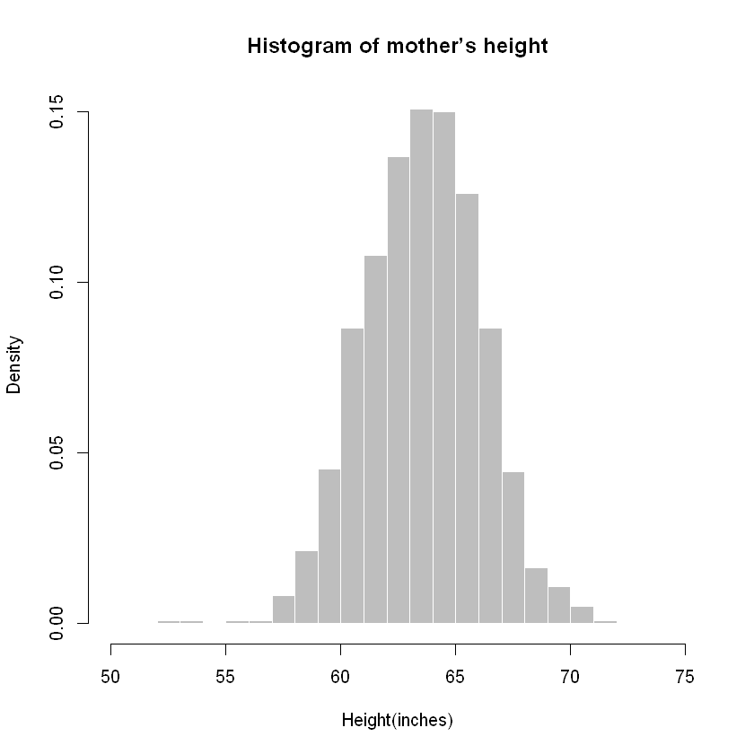

```r
table(babies[,5])
babies<-babies[-which(babies[,5]==99),]
hist(babies$height,
     main="Histogram of mother’s height",
     xlab="Height(inches)",
     xlim=c(50,75),
     breaks=c(52,53,54,55,56,57,58,59,60,61,62,63,64,65,66,67,68,69,70,71,72,75),
     col="gray",
     freq=F,border="white")
```

#### FIGURE 1.3. Histogram of mother’s height for 1214 mothers in the CHDS subset.

```
  1   2   3   4   5   6   7   9
 77 118  66  19 154  27  19   4
```

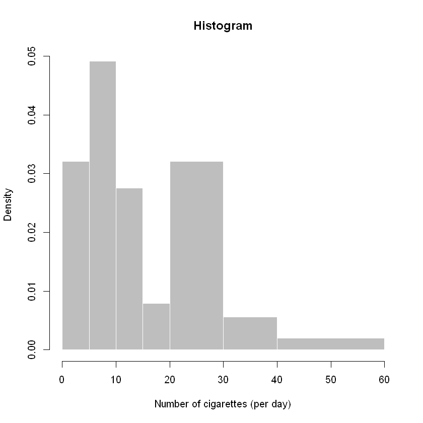

```r
babies_all<-read.table("babies23.data", header=T)
#table(babies_all[,21])
#head(babies_all)
smoke<-subset(babies_all,babies_all$smoke==1)#抽菸的先取出

#缺失值刪掉
table(smoke[23])
smoke<-smoke[-which(smoke[23]==9), ]


#number  - number of cigs smoked per day for past and current smokers  0=never, 1=1-4,
#2=5-9, 3=10-14, 4=15-19, 5=20-29, 6=30-39, 7=40-60, 8=60+, 9=smoke but don't know,
#98=unknown, 99=not asked
#把資料做還原
smoke[which(smoke[23]==3),23]<-12
smoke[which(smoke[23]==4),23]<-18
smoke[which(smoke[23]==5),23]<-24
smoke[which(smoke[23]==6),23]<-36
smoke[which(smoke[23]==7),23]<-50
smoke[which(smoke[23]==1),23]<-3
smoke[which(smoke[23]==2),23]<-6


hist(smoke$number,
     main="Histogram",
     xlab="Number of cigarettes (per day)",
     xlim=c(0,60),col="gray",
     freq=F,border="white",
     breaks = c(0,5,10,15,20,30,40,60))
```

#### FIGURE 1.4. Histogram of the number of cigarettes smoked per day for the 484 mothers who smoked in the CHDS subset.

```r
Number_of_cigarettesr<-c("0-5", "5–10","10–15","15–20","20-30","30-40","40-60","Total")
Percent_of_smokers<-c(16,25,14,4,32,5,4,100)
TABLE1_3<- cbind(Number_of_cigarettesr,Percent_of_smokers)
colnames(TABLE1_3) <- c("Number_of_cigarettesr", "Percent_of_smokers")
TABLE1_3
```

| Number_of_cigarettesr | Percent_of_smokers |
| --- | --- |
| 0-5 | 16 |
| 5–10 | 25 |
| 10–15 | 14 |
| 15–20 | 4 |
| 20-30 | 32 |
| 30-40 | 5 |
| 40-60 | 4 |
| Total | 100 |

#### TABLE 1.3. Distribution of the number of cigarettes smoked per day for 484 mothers in the CHDS subset who smoked during their pregnancy, rounded to the nearest percent.

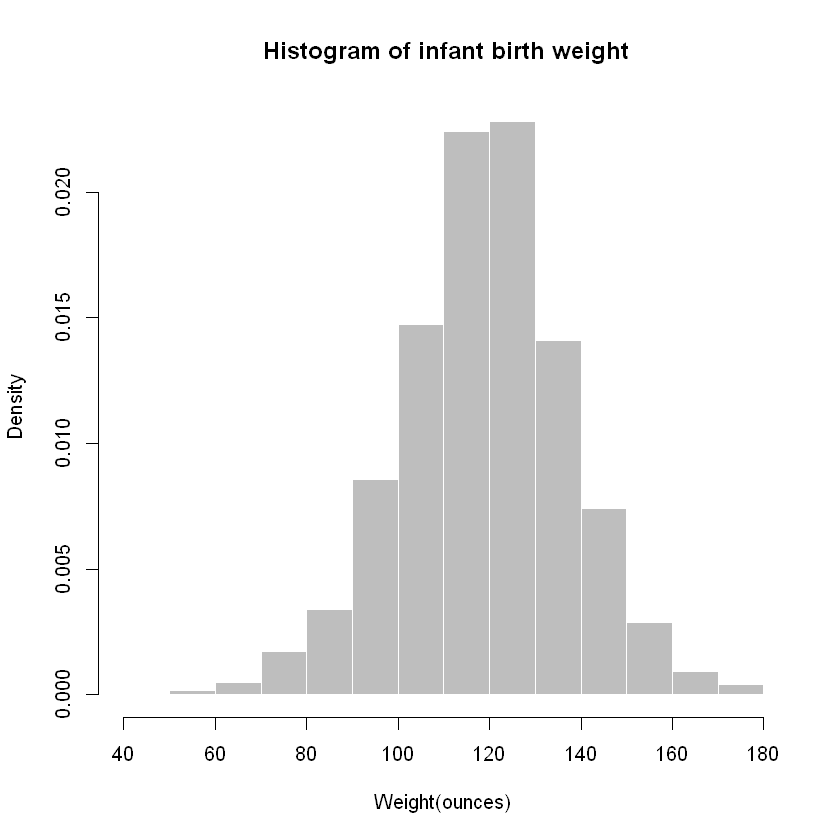

```r
hist(babies$bwt,
     main=" Histogram of infant birth weight",
     xlab="Weight(ounces)",
     xlim=c(40,180),
     breaks=10,
     col="gray",
     freq=F,
     border="white")
```

## Numerical Summaries

- A measure of location is a statistic that represents the center of the data distribution.
- One such measure is the mean # $$\bar{x}=\displaystyle\frac{1}{n}\sum\limits_{i=1}^{n}x_i$$
- One such measure is the standard deviation (SD). # $$SD(x)=\displaystyle\sqrt{\frac{1}{n}\sum\limits_{i=1}^{n}(x_{i}-\bar{x})^2}$$
- An alternative measure of location is the median.

## Five-Number Summary

- The ﬁve-number summary provides a measure of location and spread plus some additional information.

```r
table(babies$weight)
babies_1200<-babies[-(which(babies$weight==999)),6]#缺失值999拿掉
summary(babies_1200)
```

```
 87  89  90  91  92  93  94  95  96  97  98  99 100 101 102 103 104 105 106 107
  1   2   3   1   1   4   2   5   4   3   6   6  18   3  10  15  13  27   7  15
108 109 110 111 112 113 114 115 116 117 118 119 120 121 122 123 124 125 126 127
 16  10  66   9  29  14  10  42  16  21  32   9  55   9  22  15  21  68  15  25
128 129 130 131 132 133 134 135 136 137 138 139 140 141 142 143 144 145 146 147
 18  10  78   3  23   9   9  61  11  15   8   4  41   2  10   6   4  42   4   9
148 149 150 151 152 153 154 155 156 157 158 159 160 162 163 164 165 168 169 170
  9   4  31   1   2   2   5  18   5   3   1   4  16   4   1   2   8   1   2  10
171 174 175 176 177 178 180 181 182 185 189 190 191 192 196 197 198 200 202 210
  1   1   8   1   2   2   7   1   2   4   1   4   1   1   1   1   1   2   1   2
215 217 220 228 250 999
  3   1   1   1   1  17
```

```
   Min. 1st Qu.  Median    Mean 3rd Qu.    Max.
   87.0   114.0   125.0   128.6   139.0   250.0
```

#### TABLE 1.4. Five-number summary for the weights (in pounds) of 1200 mothers in the CHDS subset.

## Box-and-Whisker Plot

- A box-and-whisker plot is another type of graphical representation of data. It contains more information than a ﬁve-number summary but not as much information as a histogram.

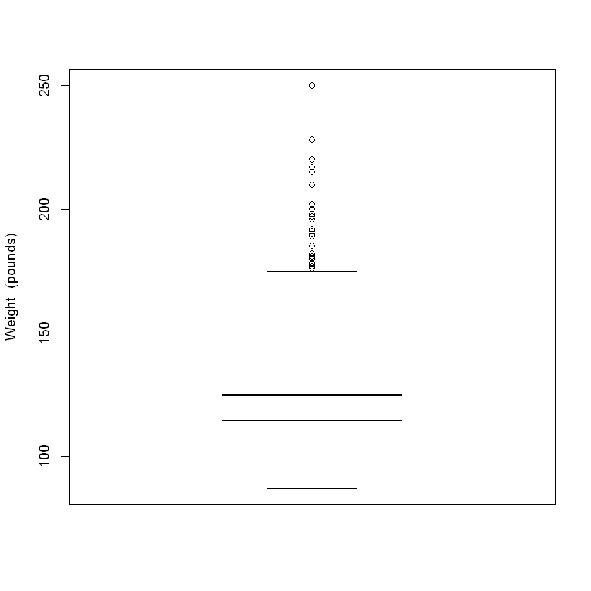

```r
boxplot(babies_1200,
        ylab="Weight  (pounds)")
```

#### FIGURE 1.6. Box-and-whisker plot of mother’s weight for 1200 mothers in the CHDS subset.

## The Normal Curve

- The standard normal curve (Figure 1.7), known as the bell curve
- It is unimodal and symmetric around 0.
- It also follows the 68-95-99.7 rule.

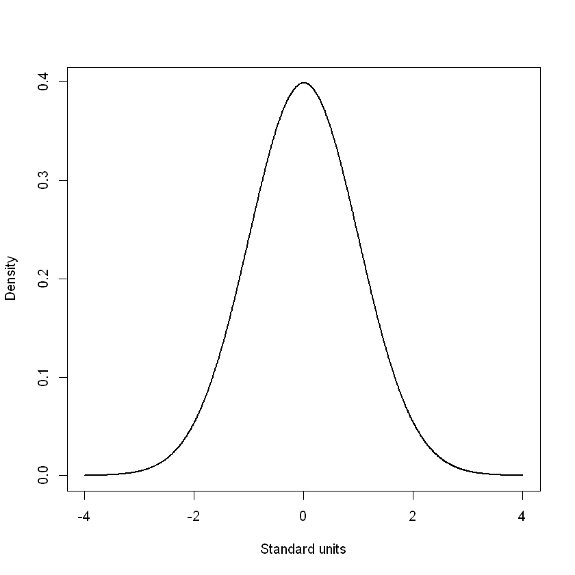

```r
x <- seq(-4, 4, length=1000)
y <- dnorm(x, mean=0, sd=1)
plot(x,
     y,
     type="l",
     lwd=2,
    xlab="Standard units",
    ylab="Density")

#summary(y)
```

#### FIGURE 1.7. The standard normal curve.

These areas and others are determined from the following analytic expression for the curve :

# $$\displaystyle\frac{1}{\sqrt{2\pi}}e^{-x^2/2}$$

Traditionally, $\phi{(z)}$ represents the area under the normal curve to the left of $z$ :

# $$\phi{(z)}=\displaystyle\int_{-\infty}^{z}\frac{1}{\sqrt{2\pi}}e^{-x^2/2}dx$$

Note that to standardize the data :

# $$\displaystyle\frac{x_{i}-\bar{x}}{SD(x)}$$

Checks for normality that are more formal than the 68-95-99.7 rule are based on the coefﬁcients of skewness and kurtosis.

# $$skewness=\displaystyle\frac{1}{n}\sum\limits_{i=1}^{n}\left(\frac{x_{i}-\bar{x}}{SD(x)}\right)^3$$

# $$kurtosis=\displaystyle\frac{1}{n}\sum\limits_{i=1}^{n}\left(\frac{x_{i}-\bar{x}}{SD(x)}\right)^4$$

## Quantile Plots

- For a distribution such as the standard normal, the $q$th quantile is $z_{q}$, where # $$\phi{(z_{q})}=q\ ,\qquad0 < q < 1$$
- The normal-quantile plot, also known as the normal-probability plot

```r
install.packages("moments")
library(moments)
```

[output not shown]

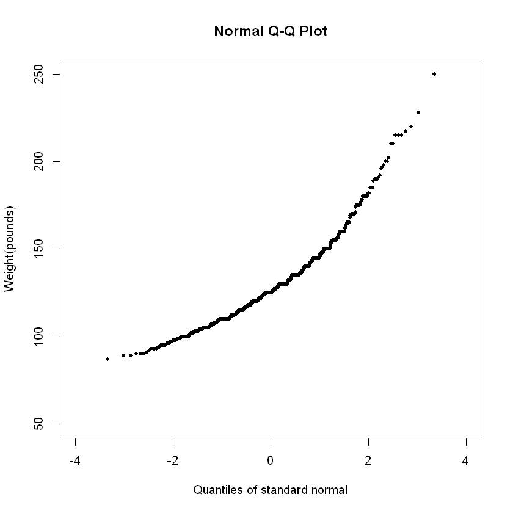

```r
qqnorm(babies_1200,
        xlab = "Quantiles of standard normal",
        ylab = "Weight(pounds)",
        xlim=c(-4,4),
        ylim=c(50,250),
        pch=20)
```

#### FIGURE 1.9. Normal quantile plot of mother’s weight for 1200 mothers in the CHDSsubset.

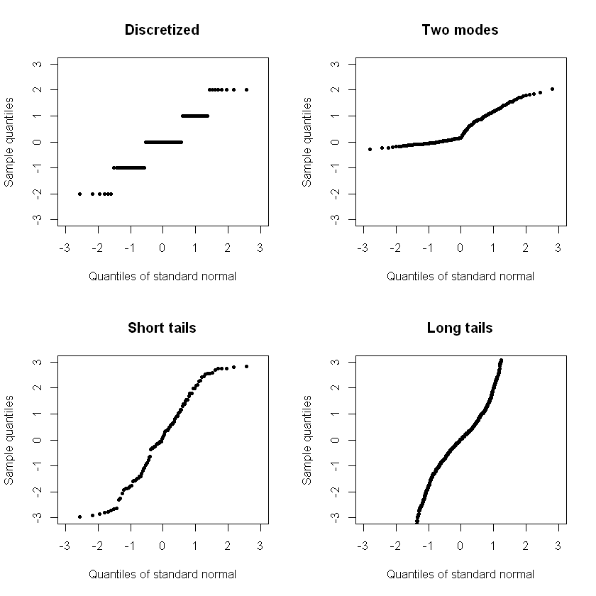

```r
par(mfrow = c(2, 2))

x<-c(rnorm(100,0,1))
x<-round(x, digits=0.0001)
qqnorm(x,main="Discretized",xlab = "Quantiles of standard normal", ylab = "Sample quantiles",xlim=c(-3,3),ylim=c(-3,3),pch=20)

x <- c(rnorm(100,0,0.1),rnorm(100,1,0.5))
qqnorm(x,main="Two modes",xlab = "Quantiles of standard normal", ylab = "Sample quantiles",xlim=c(-3,3),ylim=c(-3,3),pch=20)

x<-runif(100,-3,3)
qqnorm(x,main="Short tails",xlab = "Quantiles of standard normal", ylab = "Sample quantiles",xlim=c(-3,3),ylim=c(-3,3),pch=20)

x<-rcauchy(1000, location = 0, scale = 1)
qqnorm(x,main="Long tails",xlab = "Quantiles of standard normal", ylab = "Sample quantiles",xlim=c(-3,3),ylim=c(-3,3),pch=20)
```

#### FIGURE 1.10. Examples of normal quantile plots.

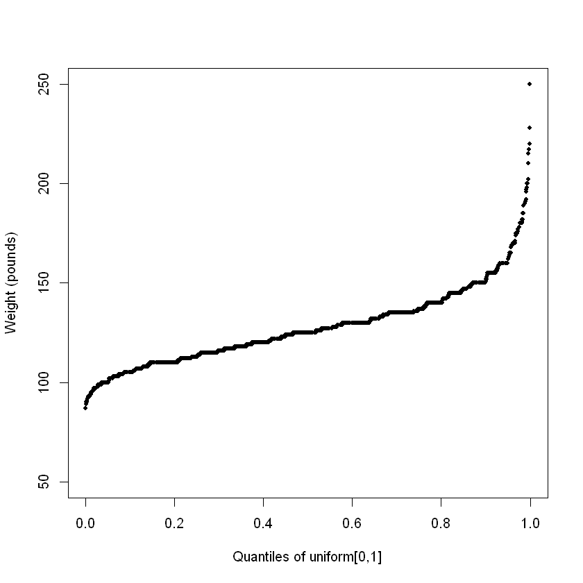

```r
y<-babies_1200
x<-runif(babies_1200, min = 0, max = 1)
qqplot(x,
       y,
       xlab = "Quantiles of uniform[0,1]",
       ylab = "Weight (pounds)",ylim=c(50,250),
       pch=20)
```

#### FIGURE 1.11. Uniform-quantile plot of mother’s weight for 1200 mothers in the CHDS subset.

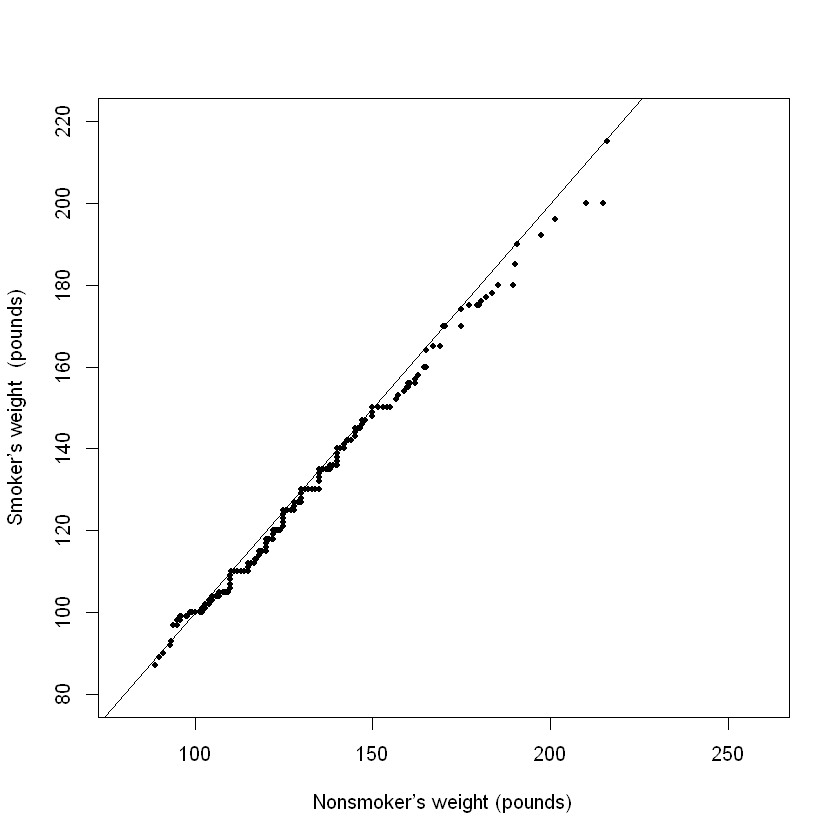

```r
NonSmoker<-babies[which(babies[7]==0),]
Smoker<-babies[which(babies[7]==1),]
qqplot(NonSmoker[,6],
       Smoker[,6],
       xlab = "Nonsmoker’s weight (pounds)",
       ylab = "Smoker’s weight  (pounds)",
       xlim=c(80,260),ylim=c(80,220),,pch=20)
abline(a=0,b=1)
```

#### FIGURE 1.12. Quantile-quantile plot of mother’s weight for smokers (484) and nonsmokers (752) in the CHDS subset; superimposed is a line of slope 1 and intercept 0.

## Cross-tabulations

- Distribution tables for subgroups of the data are called cross-tabulations.
- They allow for comparisons of distributions across more homogeneous subgroups.

[output not shown]

#### TABLE 1.5. Cross-tabulation of infant body length (in inches) for smokers and nonsmokers for a sample of 663 babies from the CHDS.

## Bar Charts and Segmented Bar Charts

```r
NonSmoker<-babies[which(babies[7]==0),]
Smoker<-babies[which(babies[7]==1),]
head(NonSmoker)
```

|  | bwt | gestation | parity | age | height | weight | smoke |
| --- | --- | --- | --- | --- | --- | --- | --- |
| 1 | 120 | 284 | 0 | 27 | 62 | 100 | 0 |
| 2 | 113 | 282 | 0 | 33 | 64 | 135 | 0 |
| 4 | 123 | 999 | 0 | 36 | 69 | 190 | 0 |
| 6 | 136 | 286 | 0 | 25 | 62 | 93 | 0 |
| 7 | 138 | 244 | 0 | 33 | 62 | 178 | 0 |
| 8 | 132 | 245 | 0 | 23 | 65 | 140 | 0 |

| marital status | Percent of mothers | Percent smokers in each group |
| --- | --- | --- |
| **All** | 100 | 30 |
| **Marital status:Married** | 90 | 27 |
| **Marital status:Single** | 10 | 55 |

| education level | Percent of mothers | Percent smokers in each group |
| --- | --- | --- |
| **Educational level:Under 12** | 21 | 55 |
| **Educational level:12** | 46 | 29 |
| **Educational level:Over 12** | 33 | 15 |

| age | Percent of mothers | Percent smokers in each group |
| --- | --- | --- |
| **Maternal age:Under 18** | 5 | 43 |
| **Maternal age:18–19** | 9 | 44 |
| **Maternal age:20-24** | 35 | 34 |
| **Maternal age:25-29** | 32 | 23 |
| **Maternal age:30-34** | 15 | 21 |
| **Maternal age:Over34** | 4 | 26 |

#### TABLE 1.6. Population characteristics and prevalence of maternal smoking among 305,730 births to white Missouri residents, 1979–1983 (Malloy et al. [MKLS88]).

[figure not shown]

```r
par(mfrow = c(1, 2))
# Create the input vectors.
colors <- c("gray","steelblue4")
marital_status<- c("Married","Single")
regions<- c("Nonsmoker","smoker")
# Create the matrix of the values.
Values <- matrix(c(27,55,73,45),nrow=2,ncol=2,byrow=TRUE)
# Create the bar chart.
barplot(Values,main="Missouri study",names.arg=marital_status,xlab="marital_status",ylab="Percentage",col=colors)
# Add the legend to the chart.
legend("topleft", regions, cex=1.3, fill=colors)

# Create the input vectors.
colors <- c("gray","steelblue4")
marital_status<- c("smoker","Nonsmoker")
regions<- c("Users","Nonusers")
# Create the matrix of the values.
Values <- matrix(c(67,75,33,25),nrow=2,ncol=2,byrow=TRUE)
#Values
# Create the bar chart.
barplot(Values,main="CHDS study",names.arg=marital_status,xlab="CHDS study",ylab="Percentage",col=colors)
# Add the legend to the chart.
legend("topleft", regions, cex=1.3, fill=colors)
```

#### FIGURE 1.13. Bar charts of smoking prevalence by marital status (left) for mothers in the Missouri study (Malloy et al. [MKLS88]) and contraceptive use by smoking prevalence (right) for mothers in the CHDS study (Yerushalmy [Yer71]).